# An Introduction to Latent Order LOGistic (LOLOG) Network Models

### The Effect of Wealth

We can test whether edge probabilities are a function of wealth:

```r
flomodel.03 <- lolog(flomarriage~edges+nodeCov('wealth'))
```

```
#> Initializing using variational fit
#>
#>  Model is dyad independent. Replications are redundant. Setting nReplicates <- 1L.
#> Model is dyad independent. Returning maximum likelihood estimate.
```

```r
summary(flomodel.03)
```

```
#>                observed_statistics       theta          se pvalue
#> edges                           20 -2.59492903 0.536051763 0.0000
#> nodecov.wealth                2168  0.01054591 0.004674236 0.0241
```

Yes, there is a significant positive wealth effect on the probability of a tie.

### Reciprocity

Let’s try a model or two on:

Is there a statistically significant tendency for ties to be reciprocated (‘mutuality’)?

```r
data(samplk)
ls() # directed data: Sampson's Monks
```

[output not shown]

```r
samplk3
```

```
#>  Network attributes:
#>   vertices = 18
#>   directed = TRUE
#>   hyper = FALSE
#>   loops = FALSE
#>   multiple = FALSE
#>   bipartite = FALSE
#>   total edges= 56
#>     missing edges= 0
#>     non-missing edges= 56
#>
#>  Vertex attribute names:
#>     cloisterville group vertex.names
#>
#> No edge attributes
```

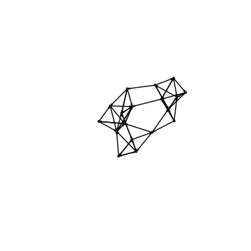

```r
plot(samplk3)
```

```r
sampmodel.01 <- lolog(samplk3~edges+reciprocity, verbose=FALSE)
summary(sampmodel.01)
```

```
#>             observed_statistics     theta        se pvalue
#> edges                        56 -1.780017 0.1710626  0e+00
#> reciprocity                  15  2.487496 0.6743379  2e-04
```

## Modeling Larger Networks

Let’s try a larger network. First we will fit a dyad independent model.

```r
data(faux.mesa.high)
mesa <- faux.mesa.high
mesa
```

```
#>  Network attributes:
#>   vertices = 205
#>   directed = FALSE
#>   hyper = FALSE
#>   loops = FALSE
#>   multiple = FALSE
#>   bipartite = FALSE
#>   total edges= 203
#>     missing edges= 0
#>     non-missing edges= 203
#>
#>  Vertex attribute names:
#>     Grade Race Sex
#>
#> No edge attributes
```

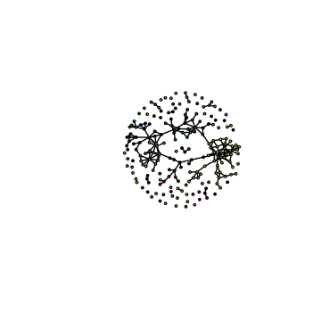

```r
plot(mesa, vertex.col='Grade')
```

```r
#legend('bottomleft',fill=7:12,legend=paste('Grade',7:12),cex=0.75)
mesa %v% "GradeCat" <- as.character(mesa %v% "Grade")
fauxmodel.01 <- lolog(mesa ~edges + nodeMatch('GradeCat') + nodeMatch('Race'))
```

```
#> Initializing using variational fit
#>
#>  Model is dyad independent. Replications are redundant. Setting nReplicates <- 1L.
#> Model is dyad independent. Returning maximum likelihood estimate.
```

```r
summary(fauxmodel.01)
```

```
#>                    observed_statistics      theta        se pvalue
#> edges                              203 -6.2254111 0.1737005 0.0000
#> nodematch.GradeCat                 163  2.8278899 0.1773356 0.0000
#> nodematch.Race                     103  0.4266748 0.1427599 0.0028
```

Now lets try adding in transitivity and 2-stars (a measure of degree spread)

```r
# This may take a minute or two
fauxmodel.02 <- lolog(mesa ~edges + nodeMatch('GradeCat') + nodeMatch('Race') + triangles + star(2), verbose=FALSE)
summary(fauxmodel.02)
```

```
#>                    observed_statistics       theta         se pvalue
#> edges                              203 -6.32253753 0.23009490 0.0000
#> nodematch.GradeCat                 163  2.59264481 0.19642150 0.0000
#> nodematch.Race                     103  0.41817975 0.16839142 0.0130
#> triangles                           62  3.07545054 0.75245219 0.0000
#> star.2                             659  0.02291813 0.05504247 0.6771
```

We see strong eidence of additional transitivity, but little evidence that the degrees have higher spread than expected given the other terms. With LOLOG models, we avoid some of the degeneracy problems present in ERGM models. Let’s try the same model in ergm

```r
fauxmodel.01.ergm <- ergm(mesa ~edges + nodematch('GradeCat') + nodematch('Race') + triangles + kstar(2))
```

```
#> Starting maximum likelihood estimation via MCMLE:
#> Iteration 1 of at most 20:
#> Error in ergm.MCMLE(init, nw, model, initialfit = (initialfit <- NULL), : Number of edges in a simulated network exceeds that in the observed by a factor of more than 20. This is a strong indicator of model degeneracy or a very poor starting parameter configuration. If you are reasonably certain …
```

Of course it is highly recommended that you take great care in selecting terms for use with ergm for precisly the reason that many can lead to model degeneracy. A much better choice here for the ergm model would have been to use gwesp and gwdegree in place of triangles and 2-stars.

## Model Terms Available for LOLOG Estimation and Simulation

Model terms are the expressions (e.g. triangle) used to represent predictors on the right-hand size of equations used in: - calls to lolog (to estimate an ergm model) - calls to simulate (to simulate networks from an lolog model fit) - calls to calculateStatistics (to obtain measurements of network statistics on a dataset)

### Terms Provided with lolog

For a list of available terms that can be used to specify an ERGM, type:

```r
help('lolog-terms')
```

### Coding New Terms

Full details on coding new terms is beyond the scope of this document. However, lolog provides facilities for extending the package to provide new terms. An example of this can be created via

```r
lologPackageSkeleton()
```

and then at the command prompt, run

```bash
R CMD build LologExtension
R CMD INSTALL LologExtension_1.0.tar.gz
```

A new package will be installed implementing the minDegree (minimum degree) statistic.

Alternatively, C++ extensions can be added directly from R without the need of any pacakge infustructure via the inlining features of the Rcpp package. lolog provides an inline plugin for this feature. For details, see

```r
help("inlineLologPlugin")
```

## Network Simulation and Computation

Network Statistics can be calculated using the calculateStatistics function

```r
calculateStatistics(mesa ~ edges + triangles + degree(0:15))
```

```
#>     edges triangles  degree.0  degree.1  degree.2  degree.3  degree.4
#>       203        62        57        51        30        28        18
#>  degree.5  degree.6  degree.7  degree.8  degree.9 degree.10 degree.11
#>        10         2         4         1         2         1         0
#> degree.12 degree.13 degree.14 degree.15
#>         0         1         0         0
```

Simulating from a fit lolog object with

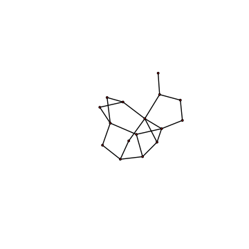

```r
nets <- simulate(flomodel.03,nsim=10) #Generates a list of BinaryNet objects
plot(nets[[1]])
```

Voila. Of course, yours will look somewhat different. Note that the objects created are BinaryNet objects unless the convert parameter is set to TRUE, in which case they are network objects.

## Working with BinaryNet objects

BinaryNets are network data structures native to the lolog package. They are special in a couple ways. First, they have a sparse representation of missingness, such that a directed network where halve of the nodes have been egocentrically sampled takes the same amount of space a a simple fully observed network. Secondly, they may be passed up and down easily from R to C++ and visa versa. Finally, they are extensible on the C++ level, so that their implementation may be replaced. For example, it might be useful to put in a file backed storage system for large problems.

BinaryNets can be coerced to and from network objects.

```r
data(sampson)

#coersion
net <- as.BinaryNet(samplike)
nw2 <- as.network(net)
print(nw2)
```

```
#>  Network attributes:
#>   vertices = 18
#>   directed = TRUE
#>   hyper = FALSE
#>   loops = FALSE
#>   multiple = FALSE
#>   bipartite = FALSE
#>   total edges= 88
#>     missing edges= 0
#>     non-missing edges= 88
#>
#>  Vertex attribute names:
#>     cloisterville group vertex.names
#>
#> No edge attributes
```

```r
#dyad Extraction
net[1:2,1:5]
```

```
#>       [,1]  [,2]  [,3]  [,4]  [,5]
#> [1,] FALSE  TRUE  TRUE FALSE  TRUE
#> [2,]  TRUE FALSE FALSE FALSE FALSE
```

```r
net$outNeighbors(c(1,2,3))
```

```
#> [[1]]
#> [1]  2  3  5  8 12 14
#>
#> [[2]]
#> [1]  1  7 12 14 15
#>
#> [[3]]
#> [1]  1  2 13 17 18
```

```r
#dyad assignment
net[1,1:5] <- rep(NA,5)
net[1:2,1:5]
```

```
#>       [,1]  [,2]  [,3]  [,4]  [,5]
#> [1,] FALSE    NA    NA    NA    NA
#> [2,]  TRUE FALSE FALSE FALSE FALSE
```

```r
net[1:2,1:5,maskMissing=FALSE] #remove the mask over missing values and see nothing was really changed
```

```
#>       [,1]  [,2]  [,3]  [,4]  [,5]
#> [1,] FALSE  TRUE  TRUE FALSE  TRUE
#> [2,]  TRUE FALSE FALSE FALSE FALSE
```

```r
#node variables
net$variableNames()
```

```
#> $discrete
#> [1] "cloisterville" "group"         "na"            "vertex.names"
#>
#> $continuous
#> character(0)
```

```r
net[["group"]]
```

```
#>  [1] Turks    Turks    Outcasts Loyal    Loyal    Loyal    Turks
#>  [8] Loyal    Loyal    Loyal    Loyal    Turks    Outcasts Turks
#> [15] Turks    Turks    Outcasts Outcasts
#> Levels: Loyal Outcasts Turks
```

```r
net[["rnorm"]] <- rnorm(18)
net[["rnorm"]]
```

```
#>  [1]  0.784508383  0.307182653 -0.260096284 -0.444246504  0.851571881
#>  [6] -0.614638793 -0.244948832 -0.174361236  0.504134685 -0.368919616
#> [11]  0.307895293  2.492487713 -1.797207011 -0.383565328 -0.001773056
#> [16]  0.854878936  0.532018112 -1.280145601
```

```r
#See available methods
#print(DirectedNet)
#print(UndirectedNet)
```

All user facing functions in the lolog package accept BinaryNets as arguments, and will convert network objects to BinaryNets automatically.

## Order Dependent Terms

LOLOG allows for network statistics tat depend not just on the network, but also the (unobserved) order in which syads were ‘added’ to the network. One model of this class is the Babarasi-Albert preferential attachment model, which is closely approximated by a lolog model with an edges and preferentialAttachment term.

For each order dependent statistic, one or more order independent statistics must be specified as moment matching targets. In this case, w will use two-star

```r
flomodel.04 <- lolog(flomarriage ~ edges() + preferentialAttachment(), flomarriage ~ star(2), verbose=FALSE)
summary(flomodel.04)
```

```
#>                        observed_statistics      theta       se pvalue
#> edges                                   20 -1.6961715 2.558991 0.5074
#> preferentialAttachment                  NA -0.0354842 1.037945 0.9727
```

## Examining the Quality of Model Fit - GOF

LOLOGs are generative models - that is, they represent the process that governs tie formation at a local level. These local processes in turn aggregate up to produce characteristic global network properties, even though these global properties are not explicit terms in the model. One test of whether a model “fits the data” is therefore how well it reproduces these global properties. We do this by choosing a network statistic that is not in the model, and comparing the value of this statistic observed in the original network to the distribution of values we get in simulated networks from our model.

We begin by comparing the degree structure of simulated nets compared to the observed (red)

```r
gdeg <- gofit(flomodel.03, flomarriage ~ degree(0:10))
gdeg
```

```
#>           obs min mean max    pvalue
#> degree.0    1   0 1.06   5 0.9523094
#> degree.1    4   0 3.20   8 0.6687044
#> degree.2    2   0 4.20   9 0.2664468
#> degree.3    6   0 3.83   7 0.2033616
#> degree.4    2   0 2.30   7 0.8528553
#> degree.5    0   0 0.98   4 0.3524339
#> degree.6    1   0 0.32   3 0.2578741
#> degree.7    0   0 0.09   1 0.7543497
#> degree.8    0   0 0.02   1 0.8869686
#> degree.9    0   0 0.00   0        NA
#> degree.10   0   0 0.00   0        NA
```

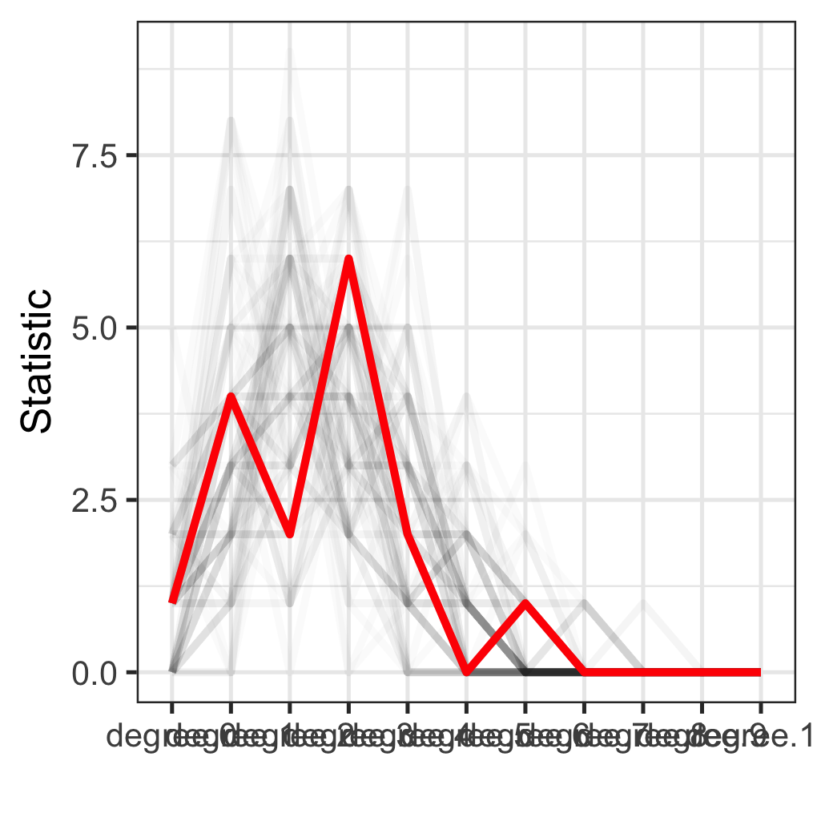

```r
plot(gdeg)
```

Next we can look at the edgewise shared partner distribution in simulated networks compared with the observed distribution(red)

```r
gesp <- gofit(flomodel.03, flomarriage ~ esp(0:5))
gesp
```

```
#>       obs min  mean max    pvalue
#> esp.0  12   3 13.71  21 0.6484374
#> esp.1   7   0  5.48  17 0.6696853
#> esp.2   1   0  1.00   7 1.0000000
#> esp.3   0   0  0.09   2 0.7975781
#> esp.4   0   0  0.02   1 0.8869686
#> esp.5   0   0  0.00   0        NA
```

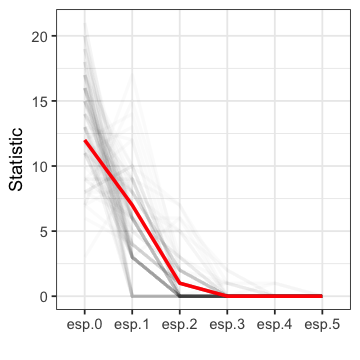

```r
plot(gesp)
```